# Lab 2 Solutions

1. Load in closing values of GE stock. Rename Adj. Close to ge.

```r
library(tidyverse)
ge <- read_csv("https://www.quandl.com/api/v3/datasets/WIKI/GE.csv")
ge <- rename(ge, ge=`Adj. Close`)
```

3. Calculate a new variable that has daily price returns on GE.

```r
ge <- select(ge, Date, ge) #want to simplify the data
ge <- arrange(ge, Date) #the data has to be sorted by Date before calculating returns
ge$ge_return <- (ge$ge - lag(ge$ge))/lag(ge$ge)*100
```

4. Calculate mean daily return between 1980 and 1990.

```r
ge80_90 <- filter(ge, Date >= as.Date("1980-01-01") & Date < as.Date("1990-01-01"))
summary(ge80_90$ge_return)
```

```
##      Min.   1st Qu.    Median      Mean   3rd Qu.      Max.
## -17.47783  -0.83292   0.00000   0.07968   0.91743  11.28250
```

5. What was the best and worst day for GE since 1990?.

```r
ge90on <- filter(ge, Date >= as.Date("1990-01-01"))
ge90on <- arrange(ge90on, ge_return)
head(ge90on, n=2)
```

```
## # A tibble: 2 x 3
##   Date          ge ge_return
##   <date>     <dbl>     <dbl>
## 1 2008-04-11 22.7      -12.8
## 2 2008-11-20  9.30     -11.1
```

```r
tail(ge90on, n=2)
```

```
## # A tibble: 2 x 3
##   Date          ge ge_return
##   <date>     <dbl>     <dbl>
## 1 2009-02-09  9.33      13.9
## 2 2009-03-10  6.75      19.7
```

The best day was March 10, 2009, the worst April 11, 2008.

6. Plot the histogram of daily returns on GE since 1990, and the time plot of daily returns since 1990. Are the two graphs consistent with each other?

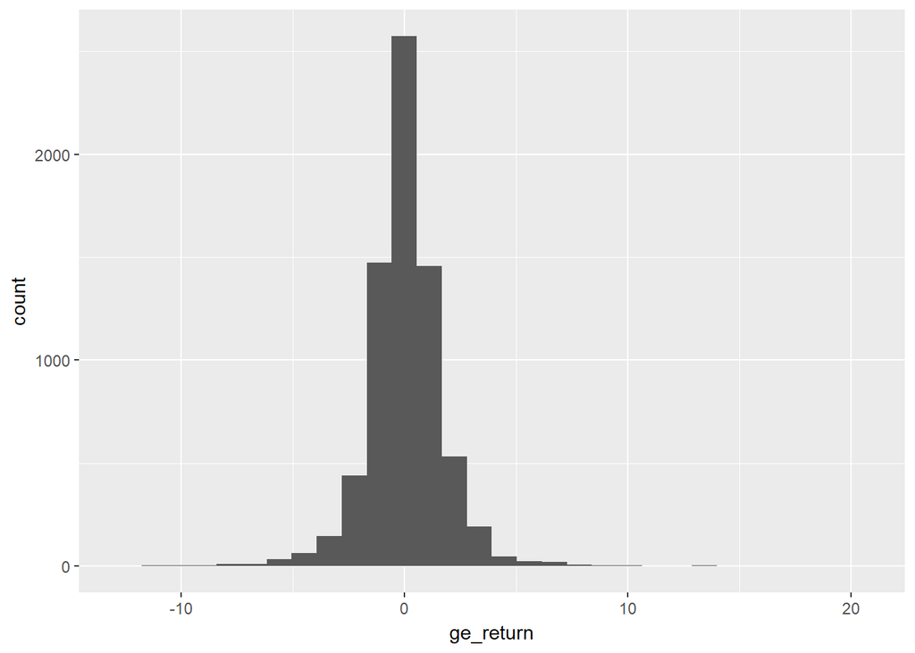

```r
ggplot(ge90on, aes(x=ge_return)) + geom_histogram()
```

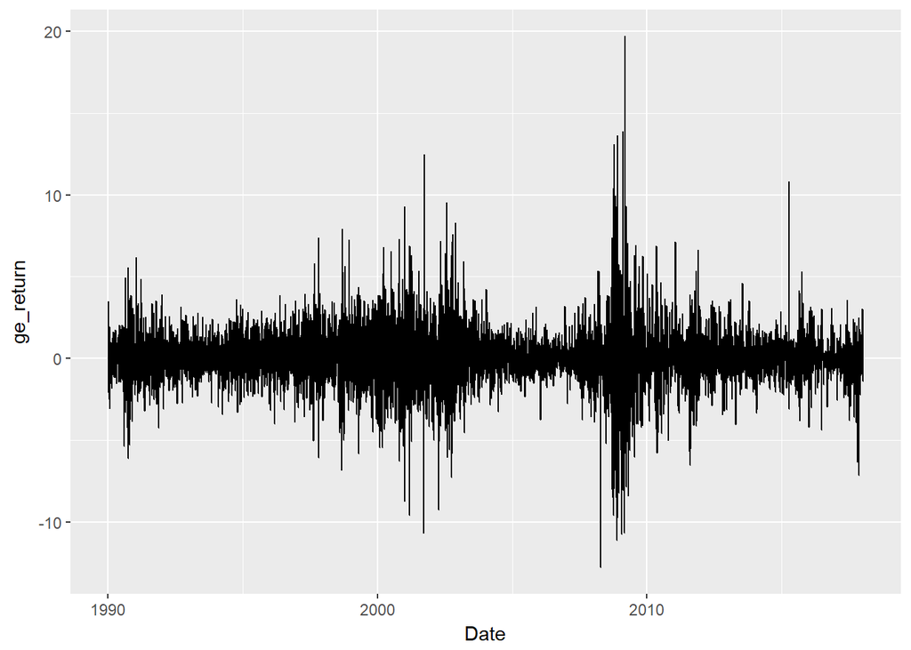

```r
ggplot(ge90on, aes(x=Date,y=ge_return)) + geom_line()
```

The two graphs are consistent with each other since they plot the same data. The range of the horizontal axis in the histogram corresponds to the range of the vertical axis on the time plot. The histogram shows that most daily returns are fairly small (roughly between -5 and +5 percent), but returns around minus and plus ten percent are possible. The time plot shows this as well.

7. Based on the graphs you created, would you say that volatility of GE prices is constant over time?

Certainly not. The time plot of daily returns clearly shows there are periods of several years when daily returns fluctuate more than in other periods. For example, we see particularly turbulent period for a few years after 2000 and then again around the 2008/09 financial crisis.

8. Create monthly data of (end of the month) adjusted closing prices on GE.

```r
library(lubridate)
ge$month <- month(ge$Date)
monthly <- filter(ge, month != lead(month))
```

9. Calculate monthly price returns on GE. What is the average monthly return? Which months were the best and worst?

```r
monthly$ret <- (monthly$ge - lag(monthly$ge))/lag(monthly$ge)*100
monthly <- arrange(monthly, ret)
monthly <- select(monthly, -ge_return) #drop the daily return
summary(monthly$ret)
```

```
##     Min.  1st Qu.   Median     Mean  3rd Qu.     Max.     NA's
## -27.6815  -3.4725   0.3324   0.8259   4.7564  25.1236        1
```

```r
head(monthly, n=2)
```

```
## # A tibble: 2 x 4
##   Date          ge month   ret
##   <date>     <dbl> <dbl> <dbl>
## 1 2009-02-27  6.48  2.00 -27.7
## 2 2009-01-30  8.96  1.00 -25.1
```

```r
tail(monthly, n=2)
```

```
## # A tibble: 2 x 4
##   Date          ge month   ret
##   <date>     <dbl> <dbl> <dbl>
## 1 2009-04-30 9.63   4.00  25.1
## 2 1962-01-31 0.330  1.00  NA
```

The worst month was February 2009, the best month was April 2009.